# Regresión cuantílica: intervalos de predicción con Random Forest Python

**Joaquín Amat Rodrigo**

*Noviembre, 2020*

Más sobre ciencia de datos: [**cienciadedatos.net**](https://cienciadedatos.net)

- [Random Forest con Python](https://www.cienciadedatos.net/documentos/py08_random_forest_python.html)
- [Gradient Boosting Probabilístico Python](https://www.cienciadedatos.net/documentos/py26-gradient-boosting-probabilistico-python.html)
- [Modelos GAMLSS](https://www.cienciadedatos.net/documentos/https://www.cienciadedatos.net/documentos/63_gamlss.html)
- [Machine learning con Python y Scikit-learn](https://www.cienciadedatos.net/documentos/py06_machine_learning_python_scikitlearn.html)

## Introducción

La predicción de una variable continua $Y$ en función de uno o varios predictores $X$ es un problema de aprendizaje supervisado que puede resolverse con múltiples métodos de *Machine Learning* y aprendizaje estadístico. Algunos de ellos, consideran que la relación entre $X$ e $Y$ es únicamente lineal, mientras que otros permiten incorporar relaciones no lineales o incluso interacciones entre predictores. De una forma u otra, todos ellos tratan de inferir la relación entre $X$ e $Y$.

El objetivo de la mayoría de estos algoritmos es predecir el valor promedio de la variable respuesta en función del valor de los predictores $E(Y|X = x)$, a esto se le conoce como estimación puntual (*point estimated*). Si bien conocer la media condicional es de utilidad, este resultado ignora otras características de la distribución de $Y$ que pueden ser claves a la hora de tomar decisiones, por ejemplo, la incertidumbre asociada.

Véase el siguiente ejemplo simulado (y muy simplificado) sobre la evolución del consumo eléctrico de todas las casas de una ciudad en función de la hora del día.

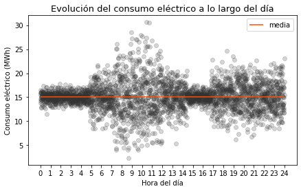

La media del consumo eléctrico es la misma durante todo el día, $\overline{consumo}$ = 15 Mwh, sin embargo, su dispersión no es constante (heterocedasticidad). Véase el resultado de predecir el consumo medio en función de la hora del día con un modelo [Random Forest](https://www.cienciadedatos.net/documentos/py08_random_forest_python.html).

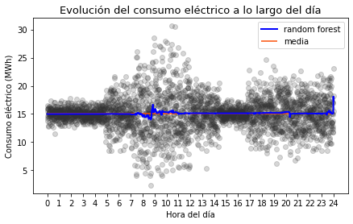

El valor predicho es muy próximo a la media real, es decir, el modelo es bueno prediciendo el consumo medio esperado. Ahora, imagínese que la compañía encargada de suministrar la electricidad debe de ser capaz de provisionar, en un momento dado, con hasta un 50% de electricidad extra respecto al promedio. Esto significa un máximo de 22.5 Mwh. Estar preparado para suministrar este extra de energía implica gastos de personal y maquinaría, por lo que la compañía se pregunta si es necesario estar preparado para producir tal cantidad durante todo el día, o si, por lo contrario, podría evitarse durante algunas horas, ahorrando así gastos.

Una forma de describir la dispersión de una variable es el uso de [cuantiles](https://es.wikipedia.org/wiki/Cuantil). El cuantil de orden $\tau$ $(0 < \tau < 1)$ de una distribución es el valor de dicha variable que marca un corte tal que, una proporción $\tau$ de valores de la población, es menor o igual que dicho valor. Por ejemplo, el cuantil de orden 0.36 deja un 36% de valores por debajo y el cuantil de orden 0.50 el 50% (se corresponde con la mediana de la distribución).

Dado que los datos se han simulado empleando distribuciones normales, se conoce el valor de los cuantiles teóricos para cada hora. Se muestra de nuevo el mismo gráfico pero esta vez añadiendo los cuantiles 0.1 y 0.9.

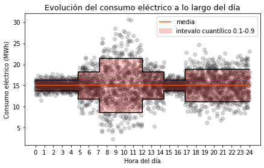

Si como resultado del modelo, además de la predicción de la media, se predice también el valor de los cuantiles, se dispone de una caracterización mayor de la distribución de la variable respuesta, y con ello se puede responder a más preguntas. Por ejemplo, en el caso de la energía, se tendría cierta seguridad al decir que, durante los intervalos de 0h a 5h y de 15h a 17h, es poco probable que se alcancen consumos de 22.5 Mwh.

Otros casos en los que conocer la distribución de cuantiles puede ser útil son:

- Identificación de regiones en las que la variable respuesta $Y$ tiene mayor dispersión en torno a su media.
- Entrenar modelos que predicen la mediana (cuantil 0.5) en lugar de la media. Estos modelos son más robustos frente a *outliers*.
- Detectar anomalías, identificando aquellas observaciones que están fuera de un determinado intervalo cuantílico.

A lo largo de este documento, se describe el algoritmo **Quantile Regression Forest**, una adaptación de *Random Forest* capaz de aprender la distribución de cuantiles y con ello, generar intervalos de predicción.

## Quantile Random Forest

Un modelo [**Random Forest**](https://www.cienciadedatos.net/documentos/py08_random_forest_python.html) está formado por un conjunto (*ensemble*) de árboles de decisión individuales, cada uno entrenado con una muestra aleatoria extraída de los datos de entrenamiento originales mediante bootstrapping). En cada árbol individual, las observaciones se van distribuyendo por bifurcaciones (nodos) generando la estructura del árbol hasta alcanzar un nodo terminal. La predicción de una nueva observación se obtiene agregando, normalmente con la media, las predicciones de todos los árboles individuales que forman el modelo. El algoritmo de **Quantile Regression Forest** propuesto por [Meinshausen, 2006](http://www.jmlr.org/papers/volume7/meinshausen06a/meinshausen06a.pdf) sigue exactamente la misma estrategia para crear el modelo, la diferencia reside en cómo se calculan las predicciones.

En lugar de promediar el valor de las observaciones en los nodos terminales de cada árbol y luego promediar el conjunto de árboles, se almacena el valor individual de todas las observaciones. De esta forma, se obtiene una estimación de la distribución de predicciones. Una vez obtenida esta distribución, se pueden calcular los cuantiles o cualquier otro estadístico.

1. Entrenar $k$ árboles, al igual que se hace en el algoritmo de *random forest*, pero almacenando la información de qué observaciones forman parte de cada nodo terminal, no solo el promedio.
2. Para una nueva observación ($X$), recorrer cada árbol del modelo hasta llegar a un nodo terminal.
3. Extraer de cada árbol las observaciones que forman parte del mismo nodo terminal que la observación predicha $X$.
4. Calcular los cuantiles de todos los valores extraídos en el paso 3.

La implementación de *random forest* de **scikitlearn** no permite acceder de forma fácil al valor de las observaciones de entrenamiento con las que se forma cada nodo terminal en cada árbol. Sin hacer modificaciones, no se pueden calcular los cuantiles tal y como propone [Meinshausen, 2006](http://www.jmlr.org/papers/volume7/meinshausen06a/meinshausen06a.pdf). Esta característica sí está disponible en la librería [**skranger**](https://skranger.readthedocs.io/en/stable/index.html), una implementación muy rápida y completa de *random forest* que, además, es compatible con **scikitlearn**.

## Ejemplo regresión

### Librerías

```python
# Librerías
# ==============================================================================
import numpy as np
import pandas as pd
import matplotlib.pyplot as plt
from scipy.stats import norm
from skranger.ensemble import RangerForestRegressor
from sklearn.model_selection import GridSearchCV
from sklearn.model_selection import ParameterGrid
from sklearn.model_selection import RepeatedKFold
import multiprocessing
```

### Datos

Se simulan datos a partir de una distribución normal con una varianza distinta dependiendo de la hora del día.

```python
# Datos simulados
# ==============================================================================
# Simulación ligeramente modificada del ejemplo publicado en
# XGBoostLSS – An extension of XGBoost to probabilistic forecasting Alexander März

np.random.seed(seed=1234)
n = 3000

# Distribución normal con varianza cambiante
x = np.linspace(start=0, stop= 24, num=n)
y = np.random.normal(
        loc   = 15,
        scale = 1 + 1.5*((4.8 < x) & (x < 7.2)) + 4*((7.2 < x) & (x < 12)) \
                + 1.5*((12 < x) & (x < 14.4)) + 2*(x > 16.8)
    )

# Cálculo del cuantil 0.1 y 0.9 para cada posición de x simulada.
cuantil_10 = norm.ppf(
                q = 0.1,
                loc   = 15,
                scale = 1 + 1.5*((4.8 < x) & (x < 7.2)) + 4*((7.2 < x) & (x < 12)) \
                        + 1.5*((12 < x) & (x < 14.4)) + 2*(x > 16.8)
             )

cuantil_90 = norm.ppf(
                q = 0.9,
                loc   = 15,
                scale = 1 + 1.5*((4.8 < x) & (x < 7.2)) + 4*((7.2 < x) & (x < 12)) \
                        + 1.5*((12 < x) & (x < 14.4)) + 2*(x > 16.8)
             )
```

### Modelo

Se entrena un modelo *random forest* utilizando validación cruzada para encontrar los hiperparámetros óptimos. Para conocer más detalles sobre el entrenamiento de un modelo *random forest* visitar [Random Forest con Python](https://www.cienciadedatos.net/documentos/py08_random_forest_python.html)

```python
# Grid de hiperparámetros evaluados
# ==============================================================================
param_grid = {'n_estimators': [500, 1000, 2000],
              'min_node_size': [25, 50, 100, 200]
             }

# Búsqueda por grid search con validación cruzada
# ==============================================================================
grid = GridSearchCV(
        estimator  = RangerForestRegressor(seed=123, quantiles=True),
        param_grid = param_grid,
        scoring    = 'neg_root_mean_squared_error',
        n_jobs     = multiprocessing.cpu_count() - 1,
        cv         = RepeatedKFold(n_splits=5, n_repeats=1, random_state=123),
        refit      = True,
        verbose    = 0,
        return_train_score = True
       )

grid.fit(X = x.reshape(-1, 1), y = y)

# Resultados
# ==============================================================================
resultados = pd.DataFrame(grid.cv_results_)
resultados.filter(regex = '(param.*|mean_t|std_t)') \
    .drop(columns = 'params') \
    .sort_values('mean_test_score', ascending = False) \
    .head(4)
```

|  | param_min_node_size | param_n_estimators | mean_test_score | std_test_score | mean_train_score | std_train_score |
| --- | --- | --- | --- | --- | --- | --- |
| 10 | 200 | 1000 | -3.135949 | 0.161194 | -2.809182 | 0.037738 |
| 11 | 200 | 2000 | -3.136225 | 0.160197 | -2.809253 | 0.037683 |
| 9 | 200 | 500 | -3.137566 | 0.160607 | -2.808739 | 0.037674 |
| 7 | 100 | 1000 | -3.167555 | 0.164495 | -2.734589 | 0.034723 |

```python
# Mejores hiperparámetros por validación cruzada
# ==============================================================================
print("----------------------------------------")
print("Mejores hiperparámetros encontrados (cv)")
print("----------------------------------------")
print(grid.best_params_, ":", grid.best_score_, grid.scoring)

modelo_final = grid.best_estimator_
```

```
----------------------------------------
Mejores hiperparámetros encontrados (cv)
----------------------------------------
{'min_node_size': 200, 'n_estimators': 1000} : -3.135949278644832 neg_root_mean_squared_error
```

### Predicción

```python
# Se predice todo el rango de X para representar los cuantiles y la predicción media
# ==============================================================================
grid_X = np.linspace(start=min(x), stop=max(x), num=5000)
pred_cuantiles = modelo_final.predict_quantiles(
                    X         = grid_X.reshape(-1, 1),
                    quantiles = [0.1, 0.9]
                  )
pred_cuantiles = pd.DataFrame(pred_cuantiles.transpose(), columns=['q_01', 'q_90'])
pred_media     = modelo_final.predict(X=grid_X.reshape(-1, 1))
```

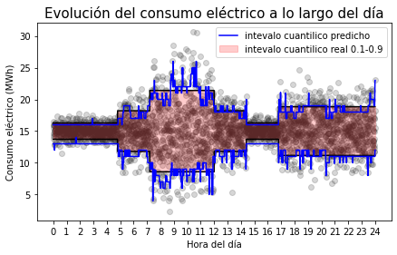

```python
# Gráfico
# ==============================================================================
fig, ax = plt.subplots(nrows=1, ncols=1, figsize=(7, 4))
ax.scatter(x, y, alpha = 0.2, c = "#333")
ax.plot(x, cuantil_10, c = "black")
ax.plot(x, cuantil_90, c = "black")
ax.plot(grid_X, pred_cuantiles.q_01, c = "blue", label='intevalo cuantilico predicho')
ax.plot(grid_X, pred_cuantiles.q_90, c = "blue")
ax.fill_between(x, cuantil_10, cuantil_90, alpha=0.2, color='red',
                label='intevalo cuantilico real 0.1-0.9')
ax.set_xticks(range(0,25))
ax.set_title('Evolución del consumo eléctrico a lo largo del día',
             fontdict={'fontsize':15})
ax.set_xlabel('Hora del día')
ax.set_ylabel('Consumo eléctrico (MWh)')
plt.legend();
```

### Cobertura

Una de las métricas empleadas para evaluar intervalos es la cobertura (*coverage*). Su valor se corresponde con el porcentaje de observaciones que caen dentro del intervalo estimado. Idealmente, la cobertura debe de ser igual a la confianza del intervalo, por lo que, en la práctica, cuanto más próximo sea su valor, mejor.

En este ejemplo, se han calculado los cuantiles 0.1 y 0.9, así que, el intervalo, tiene una confianza del 80%. Si el intervalo predicho es correcto, aproximadamente el 80% de las observaciones estarán dentro.

```python
# Predicción intervalos para las observaciones disponibles
# ==============================================================================
pred_cuantiles = modelo_final.predict_quantiles(
                    X         = x.reshape(-1, 1),
                    quantiles = [0.1, 0.9]
                  )
pred_cuantiles = pd.DataFrame(pred_cuantiles.transpose(), columns=['q_01', 'q_90'])
```

```python
# Cobertura del intervalo predicho
# ==============================================================================
dentro_intervalo = np.where(
                    (y >= pred_cuantiles.q_01) & (y <= pred_cuantiles.q_90),
                    True,
                    False
                   )
cobertura = dentro_intervalo.mean()
```

```python
print(f"Cobertura del intervalo predicho: {100 * cobertura}")
```

```
Cobertura del intervalo predicho: 81.93333333333334
```

## Detección de anomalías (Outliers)

Conocer los cuantiles condicionales de la variable respuesta permite identificar observaciones que se alejan atípicamente por encima o por debajo del valor esperado, para un determinado valor de los predictores. Véase el siguiente ejemplo en el que se trata de identificar precios anómalos de diamantes.

### Librerías

```python
# Librerías
# ==============================================================================
import numpy as np
import pandas as pd
import matplotlib.pyplot as plt
from scipy.stats import norm
import seaborn as sns
from skranger.ensemble import RangerForestRegressor
from sklearn.model_selection import GridSearchCV
from sklearn.model_selection import ParameterGrid
from sklearn.model_selection import RepeatedKFold
from sklearn.preprocessing import OneHotEncoder
import multiprocessing
```

### Datos

```python
# Datos
# ==============================================================================
datos = sns.load_dataset("diamonds")
datos = datos[datos.cut.isin(["Fair", "Good"])]
datos['cut'] = datos['cut'].cat.remove_unused_categories()
datos['price'] = np.sqrt(datos['price'])
#datos = datos[['price', 'cut', 'color', 'carat']]
datos.info()
```

```
<class 'pandas.core.frame.DataFrame'>
Int64Index: 6516 entries, 2 to 53936
Data columns (total 10 columns):
 #   Column   Non-Null Count  Dtype
---  ------   --------------  -----
 0   carat    6516 non-null   float64
 1   cut      6516 non-null   category
 2   color    6516 non-null   category
 3   clarity  6516 non-null   category
 4   depth    6516 non-null   float64
 5   table    6516 non-null   float64
 6   price    6516 non-null   float64
 7   x        6516 non-null   float64
 8   y        6516 non-null   float64
 9   z        6516 non-null   float64
dtypes: category(3), float64(7)
memory usage: 427.2 KB
```

El siguiente gráfico muestra la distribución del precio de los diamantes en función de su peso, calidad del corte y color.

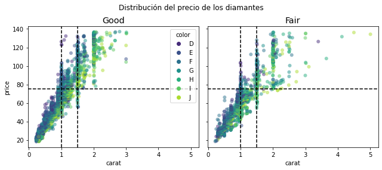

```python
fig, ax = plt.subplots(nrows=1, ncols=2, figsize=(9, 4), sharex=True,sharey=True)

for i, cut in enumerate(set(datos['cut'])):
    sns.scatterplot(
        x         = "carat",
        y         = "price",
        hue       = "color",
        palette   = "viridis",
        linewidth = 0,
        alpha     = 0.5,
        data      = datos[datos.cut==cut],
        ax        = ax[i]
    )
    ax[i].set_title(cut, fontsize  = 'x-large')
    ax[i].axvline(x=1, linestyle   ='--',  color='black')
    ax[i].axvline(x=1.5, linestyle ='--',  color='black')
    ax[i].axhline(y=75, linestyle  ='--',  color='black')

ax[1].get_legend().remove()
fig.tight_layout()
plt.subplots_adjust(top = 0.85)
fig.suptitle('Distribución del precio de los diamantes', fontsize = 12);
```

Se añaden varias anomalías simuladas en cada uno de los grupos.

```python
# Anomalías simuladas
anomalias_1 = datos.sample(frac=0.005, random_state=1234).copy()
anomalias_1['price'] = anomalias_1['price']*2.5

anomalias_2 = datos.sample(frac=0.005, random_state=1234).copy()
anomalias_2['price'] = anomalias_2['price']/2.5
```

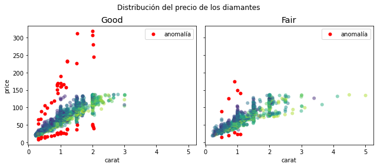

```python
fig, ax = plt.subplots(nrows=1, ncols=2, figsize=(9, 4), sharex=True,sharey=True)

for i, cut in enumerate(set(datos['cut'])):
    sns.scatterplot(
        x         = "carat",
        y         = "price",
        hue       = "color",
        palette   = "viridis",
        linewidth = 0,
        alpha     = 0.5,
        data      = datos[datos.cut==cut],
        legend    = False,
        ax        = ax[i]
    )
    sns.scatterplot(
        x         = "carat",
        y         = "price",
        color     = "red",
        linewidth = 0,
        alpha     = 1,
        data      = anomalias_1[anomalias_1.cut==cut],
        ax        = ax[i]
    )

    sns.scatterplot(
        x         = "carat",
        y         = "price",
        color     = "red",
        linewidth = 0,
        alpha     = 1,
        data      = anomalias_2[anomalias_2.cut==cut],
        label     = 'anomalía',
        ax        = ax[i]
    )
    ax[i].set_title(cut, fontsize = 'x-large')

fig.tight_layout()
plt.subplots_adjust(top = 0.85)
fig.suptitle('Distribución del precio de los diamantes', fontsize = 12);
```

```python
# Se añaden anomalías al set de datos
datos["anomalia"]       = False
anomalias_1["anomalia"] = True
anomalias_2["anomalia"] = True
datos = pd.concat([datos, anomalias_1, anomalias_2]).reset_index(drop=True)
datos.head()
```

|  | carat | cut | color | clarity | depth | table | price | x | y | z | anomalia |
| --- | --- | --- | --- | --- | --- | --- | --- | --- | --- | --- | --- |
| 0 | 0.23 | Good | E | VS1 | 56.9 | 65.0 | 18.083141 | 4.05 | 4.07 | 2.31 | False |
| 1 | 0.31 | Good | J | SI2 | 63.3 | 58.0 | 18.303005 | 4.34 | 4.35 | 2.75 | False |
| 2 | 0.22 | Fair | E | VS2 | 65.1 | 61.0 | 18.357560 | 3.87 | 3.78 | 2.49 | False |
| 3 | 0.30 | Good | J | SI1 | 64.0 | 55.0 | 18.411953 | 4.25 | 4.28 | 2.73 | False |
| 4 | 0.30 | Good | J | SI1 | 63.4 | 54.0 | 18.734994 | 4.23 | 4.29 | 2.70 | False |

### Modelo

```python
from sklearn.compose import ColumnTransformer
from sklearn.preprocessing import OneHotEncoder
from sklearn.compose import make_column_selector

# Se hace one-hot-encoding de las columnas cualitativas. Para mantener las
# columnas a las que no se les aplica ninguna transformación se tiene que indicar
# remainder='passthrough'.
cat_cols = datos.select_dtypes(include=['object', 'category']).columns.to_list()

preprocessor = ColumnTransformer(
                   [('onehot', OneHotEncoder(handle_unknown='ignore'), cat_cols)],
                   remainder='passthrough'
               )

X_train_prep = preprocessor.fit_transform(
                   datos.drop(columns=['price', 'anomalia'])
               )
```

```python
modelo = RangerForestRegressor(
    n_estimators  = 5000,
    min_node_size = 300,
    max_depth     = 3,
    quantiles     = True,
)
```

```python
modelo.fit(
    X=X_train_prep,
    y=datos.price
)
```

```
RangerForestRegressor(max_depth=3, min_node_size=300, n_estimators=5000,
                      quantiles=True, respect_categorical_features='ignore')
```

### Anomalías

```python
# Se predicen los cuantiles para cada valor observado
# ==============================================================================
pred_cuantiles = modelo.predict_quantiles(X=X_train_prep, quantiles=[0.01, 0.99])
pred_cuantiles = pd.DataFrame(pred_cuantiles.transpose(), columns=['q_01', 'q_99'])

# Se identifican las observaciones cuyo valor real está fuera del intervalo
# ==============================================================================
datos = pd.concat([datos.reset_index(), pred_cuantiles], axis=1)
datos['fuera_intervalo'] = ~datos.price.between(datos.q_01, datos.q_99)
```

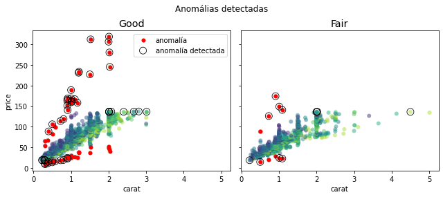

```python
fig, ax = plt.subplots(nrows=1, ncols=2, figsize=(9, 4), sharex=True,sharey=True)

for i, cut in enumerate(set(datos['cut'])):
    sns.scatterplot(
        x         = "carat",
        y         = "price",
        hue       = "color",
        palette   = "viridis",
        linewidth = 0,
        alpha     = 0.5,
        data      = datos[datos.cut==cut],
        legend    = False,
        ax        = ax[i]
    )
    sns.scatterplot(
        x         = "carat",
        y         = "price",
        color     = "red",
        linewidth = 0,
        alpha     = 1,
        data      = anomalias_1[anomalias_1.cut==cut],
        ax        = ax[i]
    )

    sns.scatterplot(
        x         = "carat",
        y         = "price",
        color     = "red",
        linewidth = 0,
        alpha     = 1,
        data      = anomalias_2[anomalias_2.cut==cut],
        label     = 'anomalía',
        ax        = ax[i]
    )

    sns.scatterplot(
        x         = "carat",
        y         = "price",
        edgecolor = 'black',
        facecolor = 'none',
        s         = 100,
        alpha     = 1,
        data      = datos[(datos.cut==cut) & (datos.fuera_intervalo==True)],
        label     = 'anomalía detectada',
        ax        = ax[i]
    )

    ax[i].set_title(cut, fontsize = 'x-large')

ax[1].get_legend().remove()
fig.tight_layout()
plt.subplots_adjust(top = 0.85)
fig.suptitle('Anomálias detectadas', fontsize = 12);
```

```python
# Anomalías reales vs anomalías detectadas
# ==============================================================================
pd.crosstab(
    index   = datos["anomalia"],
    columns = datos["fuera_intervalo"],
    margins = False
)
```

| fuera_intervalo anomalia | False | True |
| --- | --- | --- |
| False | 6496 | 20 |
| True | 25 | 41 |

## Consideraciones prácticas

Uno de los hiperparámetros de *quantile regression forest* es el número mínimo de observaciones en los nodos terminales. Cómo el algoritmo únicamente emplea aquellas observaciones para las que $Y≤y$, si son muy pocas las observaciones en los nodos terminales, apenas las habrá que cumplan la condición. Esto se traduce en que *quantile regression forest* es notablemente sensible a *overfitting* por valores bajos de este hiperparámetro. Véase cómo afecta pasar de 10 a 200 observaciones mínimas por nodo al predecir los cuantiles.

```python
# min_node_size=10
# ==============================================================================
modelo = RangerForestRegressor(n_estimators=1000, min_node_size=10, quantiles=True)
modelo.fit(X=x.reshape(-1, 1), y=y)
pred_min_node_size_10 = modelo.predict_quantiles(
                            X=x.reshape(-1, 1),
                            quantiles=[0.1, 0.9]
                        )
pred_min_node_size_10 = pd.DataFrame(
                            pred_min_node_size_10.transpose(),
                            columns=['q_01', 'q_90']
                        )
```

```python
# min_node_size=200
# ==============================================================================
modelo = RangerForestRegressor(n_estimators=1000, min_node_size=200, quantiles=True)
modelo.fit(X=x.reshape(-1, 1), y=y)
pred_min_node_size_200 = modelo.predict_quantiles(
                            X=x.reshape(-1, 1),
                            quantiles=[0.1, 0.9]
                         )
pred_min_node_size_200 = pd.DataFrame(
                            pred_min_node_size_200.transpose(),
                            columns=['q_01', 'q_90']
                         )
```

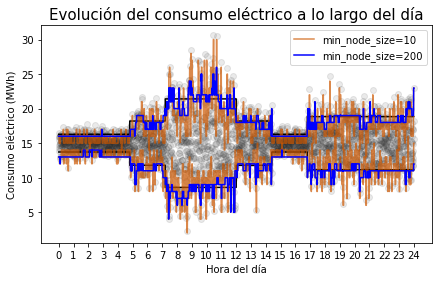

```python
fig, ax = plt.subplots(nrows=1, ncols=1, figsize=(7, 4))
ax.scatter(x, y, alpha = 0.1, c = "#333")
ax.plot(x, cuantil_10, c = "black")
ax.plot(x, cuantil_90, c = "black")
ax.plot(x, pred_min_node_size_10.q_01, c = "#cd5700", alpha = 0.7, label = 'min_node_size=10')
ax.plot(x, pred_min_node_size_10.q_90, c = "#cd5700", alpha = 0.7)
ax.plot(x, pred_min_node_size_200.q_01, c = "blue", label = 'min_node_size=200')
ax.plot(x, pred_min_node_size_200.q_90, c = "blue")
ax.set_xticks(range(0,25))
ax.set_title('Evolución del consumo eléctrico a lo largo del día',
             fontdict={'fontsize':15})
ax.set_xlabel('Hora del día')
ax.set_ylabel('Consumo eléctrico (MWh)')
plt.legend();
```

Empleando `min_node_size=10`, el modelo generado pasa por todas las observaciones de menor y mayor valor, está sobreentrenado. Por el contrario, el modelo con un mínimo de 200 observaciones por nodo (`min_node_size=200`) se ajusta mucho mejor a los cuantiles reales. Lamentablemente, no hay forma de saber a priori con exactitud cuál es el valor óptimo de este hiperparámetro.

## Bibliografía

Nicolai Meinshausen. 2006. Quantile Regression Forests. J. Mach. Learn. Res. 7 (December 2006), 983–999.

Regresión cuantílica (Quantile Regression) con R Joaquín Amat Rodrigo

Trabajo fin de máster - Tema: Regresión Cuantil Isabel Martínez Silva 30 de Junio de 2010

A gentle introduction to quantile regression for ecologists, Brian S. Cade and Barry R. Noon

März, Alexander. (2019). XGBoostLSS – An extension of XGBoost to probabilistic forecasting

An Introduction to Statistical Learning: with Applications in R (Springer Texts in Statistics)

Applied Predictive Modeling by Max Kuhn and Kjell Johnson

The Elements of Statistical Learning by T.Hastie, R.Tibshirani, J.Friedman

Introduction to Machine Learning with Python: A Guide for Data Scientists

Python Data Science Handbook by Jake VanderPlas

**¿Cómo citar este documento?**

Regresión cuantílica: intervalos de predicción en modelos Random Forest Python por Joaquín Amat Rodrigo, disponible con licencia CC BY-NC-SA 4.0 en https://www.cienciadedatos.net/documentos/py15-intervalos-prediccion-random-forest-python.html

**¿Te ha gustado el artículo? Tu ayuda es importante**

Mantener un sitio web tiene unos costes elevados, tu contribución me ayudará a seguir generando contenido divulgativo gratuito. ¡Muchísimas gracias! 😊

Este contenido, creado por Joaquín Amat Rodrigo, tiene licencia [Attribution-NonCommercial-ShareAlike 4.0 International](https://creativecommons.org/licenses/by-nc-sa/4.0/).

Se permite:

- Compartir: copiar y redistribuir el material en cualquier medio o formato.
- Adaptar: remezclar, transformar y crear a partir del material.

Bajo los siguientes términos:

- Atribución: Debes otorgar [el crédito adecuado](https://creativecommons.org/licenses/by-nc-sa/4.0/deed.es#ref-appropriate-credit), proporcionar un enlace a la licencia e [indicar si se realizaron cambios](https://creativecommons.org/licenses/by-nc-sa/4.0/deed.es#ref-indicate-changes). Puedes hacerlo de cualquier manera razonable, pero no de una forma que sugiera que el licenciante te respalda o respalda tu uso.
- NoComercial: No puedes utilizar el material para [fines comerciales](https://creativecommons.org/licenses/by-nc-sa/4.0/deed.es#ref-commercial-purposes).
- CompartirIgual: Si remezclas, transformas o creas a partir del material, debes distribuir tus contribuciones bajo la [misma licencia](https://creativecommons.org/licenses/by-nc-sa/4.0/deed.es#ref-same-license) que el original.